# AV2Simulado

## Algoritmo de Floyd-Warshall

O **algoritmo de Floyd-Warshall** é utilizado para encontrar o menor custo (ou menor caminho) entre **todos os pares de vértices** em um grafo ponderado, podendo ser direcionado ou não. Ele calcula a matriz de menores distâncias entre todos os pares, considerando todos os caminhos possíveis.

### Como funciona o Floyd-Warshall?

1. **Inicialize** uma matriz de distâncias, onde cada posição `[i][j]` contém o peso da aresta de `i` para `j` (ou infinito, se não houver ligação direta).
2. Para cada vértice intermediário `k`:
   - Para cada par de vértices `(i, j)`:
     - Atualize a distância de `i` para `j` se passar por `k` for mais barato:

       ```
       se dist[i][j] > dist[i][k] + dist[k][j]:
           dist[i][j] = dist[i][k] + dist[k][j]
       ```

3. Repita até considerar todos os vértices como intermediários.

### Características

- Resolve o problema de **todos os pares de caminhos mínimos**.
- Aceita pesos negativos (mas não pode haver ciclos negativos).
- Complexidade: O(n³), onde n é o número de vértices.

### Exemplo de aplicação

- Análise de rotas em redes de transporte, logística, telecomunicações, etc.
- Determinação do menor custo entre todas as cidades de uma malha viária.

**Resumo:**  
O algoritmo de Floyd-Warshall encontra o menor custo entre todos os pares de vértices, atualizando a matriz de distâncias ao considerar cada vértice como possível intermediário nos caminhos.

```
Passo 0: Matriz inicial de custos diretos entre as filiais
     A    B     C    D
A  0.0  3.0  10.0    ∞
B    ∞  0.0   1.0  2.0
C    ∞    ∞   0.0  4.0
D    ∞    ∞     ∞  0.0
```

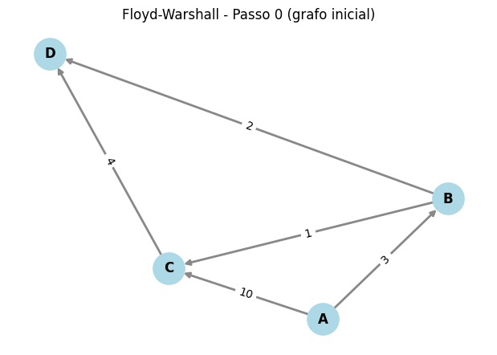

```
Passo 1: Considerando 'A' como intermediário
  - Verificamos se passar por 'A' reduz o custo entre outros pares de filiais.
  - Nenhuma atualização de custo neste passo.
  Matriz de custos atualizada:
     A    B     C    D
A  0.0  3.0  10.0    ∞
B    ∞  0.0   1.0  2.0
C    ∞    ∞   0.0  4.0
D    ∞    ∞     ∞  0.0
```

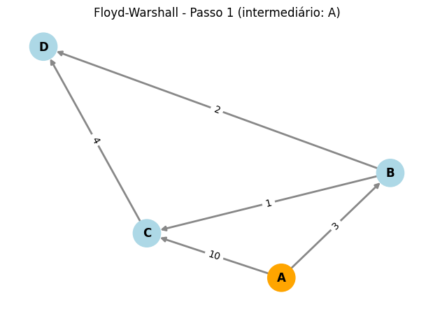

```
Passo 2: Considerando 'B' como intermediário
  - Verificamos se passar por 'B' reduz o custo entre outros pares de filiais.
    * Atualizando custo de A para C: 10 → 4 (via B)
    * Atualizando custo de A para D: inf → 5 (via B)
  Matriz de custos atualizada:
     A    B    C    D
A  0.0  3.0  4.0  5.0
B    ∞  0.0  1.0  2.0
C    ∞    ∞  0.0  4.0
D    ∞    ∞    ∞  0.0
```

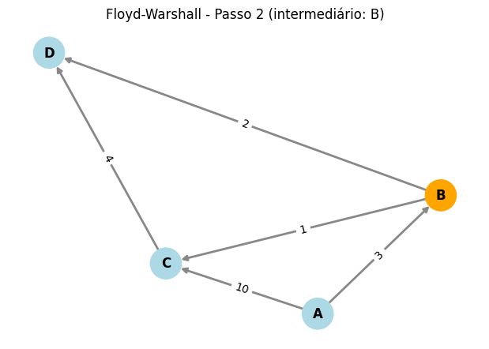

```
Passo 3: Considerando 'C' como intermediário
  - Verificamos se passar por 'C' reduz o custo entre outros pares de filiais.
  - Nenhuma atualização de custo neste passo.
  Matriz de custos atualizada:
     A    B    C    D
A  0.0  3.0  4.0  5.0
B    ∞  0.0  1.0  2.0
C    ∞    ∞  0.0  4.0
D    ∞    ∞    ∞  0.0
```

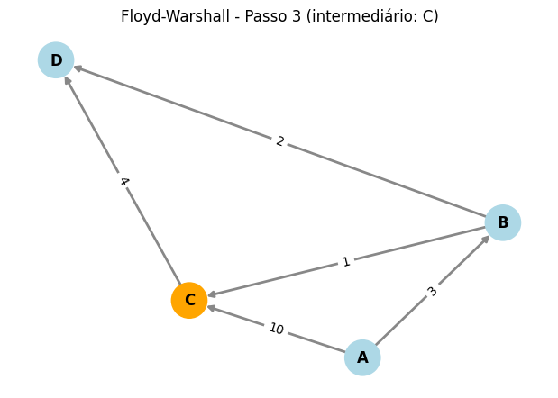

```
Passo 4: Considerando 'D' como intermediário
  - Verificamos se passar por 'D' reduz o custo entre outros pares de filiais.
  - Nenhuma atualização de custo neste passo.
  Matriz de custos atualizada:
     A    B    C    D
A  0.0  3.0  4.0  5.0
B    ∞  0.0  1.0  2.0
C    ∞    ∞  0.0  4.0
D    ∞    ∞    ∞  0.0
```

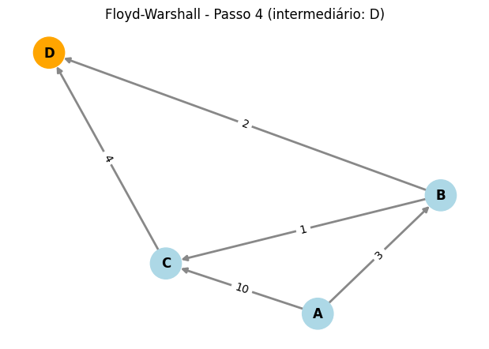

```
Matriz final de menores custos entre todos os pares (Floyd-Warshall):
     A    B    C    D
A  0.0  3.0  4.0  5.0
B    ∞  0.0  1.0  2.0
C    ∞    ∞  0.0  4.0
D    ∞    ∞    ∞  0.0
```

```python
# Floyd-Warshall passo a passo com explicação

import networkx as nx
import matplotlib.pyplot as plt
import pandas as pd

G_fw = nx.DiGraph()
G_fw.add_weighted_edges_from([
    ('A', 'B', 3),
    ('A', 'C', 10),
    ('B', 'C', 1),
    ('B', 'D', 2),
    ('C', 'D', 4)
])

vertices = ['A', 'B', 'C', 'D']
dist = {u: {v: float('inf') for v in vertices} for u in vertices}
for v in vertices:
    dist[v][v] = 0
for u, v, data in G_fw.edges(data=True):
    dist[u][v] = data['weight']

print("Passo 0: Matriz inicial de custos diretos entre as filiais")
df = pd.DataFrame(dist).T
print(df.replace(float('inf'), '∞'))

# Plot inicial
pos = nx.spring_layout(G_fw, seed=42)
plt.figure(figsize=(6,4))
nx.draw(G_fw, pos, with_labels=True, node_color='lightblue', node_size=800, font_weight='bold', edge_color='#888', width=2, arrows=True)
labels = nx.get_edge_attributes(G_fw, 'weight')
nx.draw_networkx_edge_labels(G_fw, pos, edge_labels=labels)
plt.title("Floyd-Warshall - Passo 0 (grafo inicial)")
plt.show()

passo = 1
for k in vertices:
    print(f"\nPasso {passo}: Considerando '{k}' como intermediário")
    print(f"  - Verificamos se passar por '{k}' reduz o custo entre outros pares de filiais.")
    alterou = False
    for i in vertices:
        for j in vertices:
            if dist[i][j] > dist[i][k] + dist[k][j]:
                print(f"    * Atualizando custo de {i} para {j}: {dist[i][j]} → {dist[i][k] + dist[k][j]} (via {k})")
                dist[i][j] = dist[i][k] + dist[k][j]
                alterou = True
    if not alterou:
        print("  - Nenhuma atualização de custo neste passo.")
    df = pd.DataFrame(dist).T
    print("  Matriz de custos atualizada:")
    print(df.replace(float('inf'), '∞'))

    # Plot do passo: destacar o intermediário
    plt.figure(figsize=(6,4))
    node_colors = ['orange' if n == k else 'lightblue' for n in G_fw.nodes]
    nx.draw(G_fw, pos, with_labels=True, node_color=node_colors, node_size=800, font_weight='bold', edge_color='#888', width=2, arrows=True)
    nx.draw_networkx_edge_labels(G_fw, pos, edge_labels=labels)
    plt.title(f"Floyd-Warshall - Passo {passo} (intermediário: {k})")
    plt.show()
    passo += 1

print("\nMatriz final de menores custos entre todos os pares (Floyd-Warshall):")
df = pd.DataFrame(dist).T
print(df.replace(float('inf'), '∞'))
```

### Questão 8: Caminhos Euleriano e Hamiltoniano em um grafo de cidades

Considere o grafo G(V, A) abaixo, onde os vértices representam cidades e as arestas representam estradas entre elas. O objetivo é analisar as propriedades do grafo em relação aos trajetos Hamiltonianos e Eulerianos.

Grafo G(V, A):

- Vértices: V = {A, B, C, D, E, F}
- Arestas e seus pesos:
  1. A - B: 5
  2. A - C: 7
  3. B - C: 4
  4. B - D: 6
  5. C - D: 3
  6. C - E: 8
  7. D - E: 2
  8. D - F: 9
  9. E - F: 6

Analise as afirmações abaixo:

a) No Grafo G(V, A), não é possível ter um trajeto Euleriano de “A” até “F”.

b) No Grafo G(V, A), não é possível ter um trajeto Hamiltoniano de “A” até “F”.

c) É possível construir um trajeto Euleriano entre “A” e “F”, com tamanho total igual a 28.

d) É possível construir um trajeto Hamiltoniano entre “A” e “F”, com tamanho total igual a 30.

Com base nas propriedades do grafo, qual das afirmações acima é correta? Justifique sua resposta detalhadamente, explicando:

- O que caracteriza um caminho Euleriano e um caminho Hamiltoniano.
- Como identificar se o grafo admite cada tipo de caminho entre os vértices dados.
- Se possível, mostre o caminho correspondente e o cálculo do tamanho total.

## Caminho Euleriano e Caminho Hamiltoniano

### Caminho Euleriano

Um **caminho Euleriano** em um grafo é um trajeto que percorre **todas as arestas exatamente uma vez**.

- Em grafos não direcionados, existe um caminho Euleriano entre dois vértices se e somente se **apenas esses dois vértices têm grau ímpar** (os demais têm grau par).
- Se todos os vértices têm grau par, existe um **circuito Euleriano** (começa e termina no mesmo vértice).

### Caminho Hamiltoniano

Um **caminho Hamiltoniano** é um trajeto que passa **por todos os vértices exatamente uma vez** (não necessariamente todas as arestas).

- Se existe um caminho Hamiltoniano que começa em um vértice e termina em outro, dizemos que o grafo é **semi-hamiltoniano**.
- Se existe um ciclo Hamiltoniano (começa e termina no mesmo vértice), o grafo é **hamiltoniano**.

### Como identificar no grafo?

- **Euleriano:** Verifique o grau dos vértices. Se só dois vértices têm grau ímpar (por exemplo, A e F), pode haver um caminho Euleriano de A até F.
- **Hamiltoniano:** Não há um critério simples, é preciso testar as possibilidades (busca exaustiva ou algoritmos específicos).

### Resumindo:

- **Caminho Euleriano:** percorre todas as arestas uma vez.
- **Caminho Hamiltoniano:** passa por todos os vértices uma vez.

No contexto do seu exercício, para saber se existe um caminho Euleriano ou Hamiltoniano entre A e F, analise os graus dos vértices e tente construir os caminhos conforme as definições acima.

```
Vértices de grau ímpar: ['B', 'E']
Não existe caminho Euleriano de A até F.
Existe caminho Hamiltoniano de A até F.
Caminho Hamiltoniano: ['A', 'B', 'C', 'D', 'E', 'F']
Custo total do caminho Hamiltoniano: 20
```

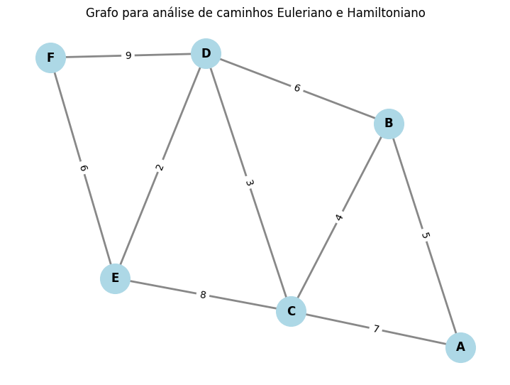

```python
# Análise detalhada de caminhos Euleriano e Hamiltoniano (Questão 8)

import networkx as nx

# Criação do grafo
G8 = nx.Graph()
G8.add_weighted_edges_from([
    ('A', 'B', 5),
    ('A', 'C', 7),
    ('B', 'C', 4),
    ('B', 'D', 6),
    ('C', 'D', 3),
    ('C', 'E', 8),
    ('D', 'E', 2),
    ('D', 'F', 9),
    ('E', 'F', 6)
])

# Verificando caminho Euleriano de A até F
grau_impar = [v for v in G8.nodes if G8.degree(v) % 2 == 1]
print("Vértices de grau ímpar:", grau_impar)
if len(grau_impar) == 2 and 'A' in grau_impar and 'F' in grau_impar:
    print("Existe caminho Euleriano de A até F.")
    # Encontrar caminho Euleriano (se existir)
    caminho_euleriano = list(nx.eulerian_path(G8, source='A'))
    print("Caminho Euleriano:", caminho_euleriano)
    custo_euleriano = sum(G8.get_edge_data(u, v)['weight'] for u, v in caminho_euleriano)
    print("Custo total do caminho Euleriano:", custo_euleriano)
else:
    print("Não existe caminho Euleriano de A até F.")

# Verificando caminho Hamiltoniano de A até F
def hamiltonian_path(G, start, end):
    from itertools import permutations
    nodes = list(G.nodes)
    nodes.remove(start)
    nodes.remove(end)
    for perm in permutations(nodes):
        path = [start] + list(perm) + [end]
        if all(G.has_edge(path[i], path[i+1]) for i in range(len(path)-1)):
            return path
    return None

caminho_hamiltoniano = hamiltonian_path(G8, 'A', 'F')
if caminho_hamiltoniano:
    print("Existe caminho Hamiltoniano de A até F.")
    print("Caminho Hamiltoniano:", caminho_hamiltoniano)
    custo_hamiltoniano = sum(G8.get_edge_data(caminho_hamiltoniano[i], caminho_hamiltoniano[i+1])['weight'] for i in range(len(caminho_hamiltoniano)-1))
    print("Custo total do caminho Hamiltoniano:", custo_hamiltoniano)
else:
    print("Não existe caminho Hamiltoniano de A até F.")

# Visualização do grafo
import matplotlib.pyplot as plt
pos = nx.spring_layout(G8, seed=42)
plt.figure(figsize=(7,5))
nx.draw(G8, pos, with_labels=True, node_color='lightblue', node_size=900, font_weight='bold', edge_color='#888', width=2)
labels = nx.get_edge_attributes(G8, 'weight')
nx.draw_networkx_edge_labels(G8, pos, edge_labels=labels)
plt.title("Grafo para análise de caminhos Euleriano e Hamiltoniano")
plt.show()
```

### Questão 9: Menor custo de transporte com Dijkstra passo a passo

Uma empresa de entregas deseja calcular o menor custo de transporte entre o depósito principal (vértice A) e os demais centros de distribuição em uma cidade. O grafo abaixo representa os centros (vértices) e as estradas (arestas com pesos):

- Vértices: A, B, C, D, E
- Arestas e seus custos:
  1. A – B: 2
  2. A – C: 5
  3. B – C: 1
  4. B – D: 2
  5. C – D: 3
  6. C – E: 1
  7. D – E: 2

Utilizando o algoritmo de Dijkstra a partir do vértice A, mostre o passo a passo do algoritmo, incluindo a tabela de menores custos (`dv`) e predecessores (`pv`) para cada vértice em cada passo, além da visualização do grafo.

## Algoritmo de Dijkstra

O **algoritmo de Dijkstra** é utilizado para encontrar o menor caminho (menor custo) entre um vértice de origem e todos os outros vértices em um grafo ponderado com pesos não negativos.

### Como funciona o Dijkstra?

1. **Inicialize** o custo de todos os vértices como infinito, exceto o vértice de origem, que recebe custo zero.
2. Marque todos os vértices como não visitados.
3. Escolha o vértice não visitado de menor custo atual.
4. Para cada vizinho desse vértice, atualize o custo se for possível chegar até ele por um caminho mais barato.
5. Marque o vértice atual como visitado.
6. Repita até visitar todos os vértices ou não houver mais atualizações possíveis.

### Características

- Garante o menor caminho em grafos com pesos positivos.
- Utiliza uma fila de prioridade (ou seleção sequencial) para escolher o próximo vértice.
- Complexidade: O(n²) para implementação simples, O(m log n) com heap (n = vértices, m = arestas).

### Exemplo de aplicação

- Cálculo de rotas mais curtas em mapas e redes de transporte.
- Otimização de custos em redes de comunicação e logística.

**Resumo:**  
O algoritmo de Dijkstra encontra o menor custo de um ponto a todos os outros em um grafo com pesos positivos, atualizando os custos mínimos e predecessores a cada passo.

```
Passo 0: Inicialização
  Custos mínimos (dv): {'A': 0, 'B': inf, 'C': inf, 'D': inf, 'E': inf}
  Predecessores (pv): {'A': None, 'B': None, 'C': None, 'D': None, 'E': None}
  Visitados: set()
```

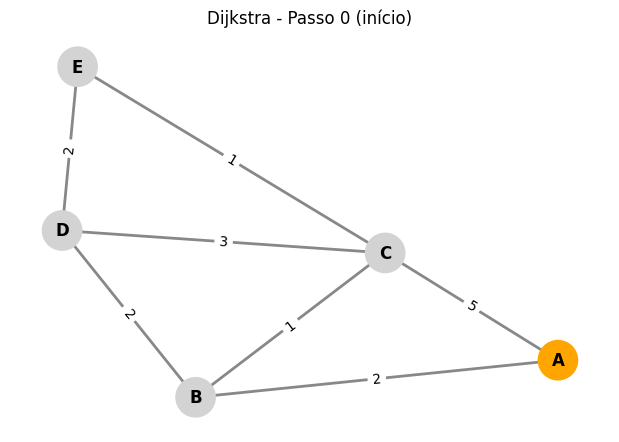

```
Passo 1:
  Vértice escolhido: A (dv=0)
    * Atualizando dv[B]: inf → 2 (via A)
    * Atualizando dv[C]: inf → 5 (via A)
  Custos mínimos (dv): {'A': 0, 'B': 2, 'C': 5, 'D': inf, 'E': inf}
  Predecessores (pv): {'A': None, 'B': 'A', 'C': 'A', 'D': None, 'E': None}
  Visitados: {'A'}
```

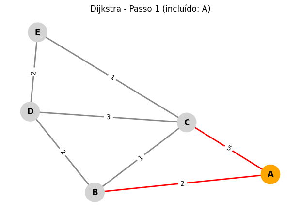

```
Passo 2:
  Vértice escolhido: B (dv=2)
    * Atualizando dv[C]: 5 → 3 (via B)
    * Atualizando dv[D]: inf → 4 (via B)
  Custos mínimos (dv): {'A': 0, 'B': 2, 'C': 3, 'D': 4, 'E': inf}
  Predecessores (pv): {'A': None, 'B': 'A', 'C': 'B', 'D': 'B', 'E': None}
  Visitados: {'A', 'B'}
```

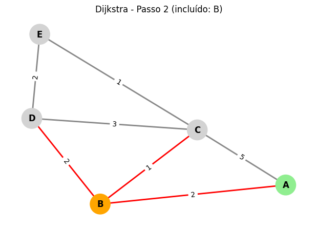

```
Passo 3:
  Vértice escolhido: C (dv=3)
    * Atualizando dv[E]: inf → 4 (via C)
  Custos mínimos (dv): {'A': 0, 'B': 2, 'C': 3, 'D': 4, 'E': 4}
  Predecessores (pv): {'A': None, 'B': 'A', 'C': 'B', 'D': 'B', 'E': 'C'}
  Visitados: {'C', 'A', 'B'}
```

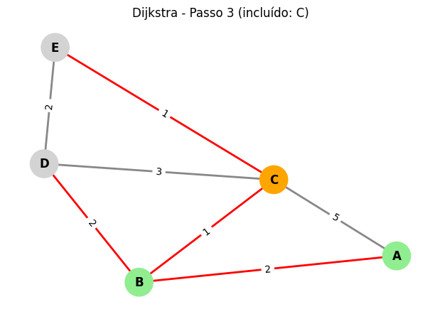

```
Passo 4:
  Vértice escolhido: D (dv=4)
  Custos mínimos (dv): {'A': 0, 'B': 2, 'C': 3, 'D': 4, 'E': 4}
  Predecessores (pv): {'A': None, 'B': 'A', 'C': 'B', 'D': 'B', 'E': 'C'}
  Visitados: {'C', 'A', 'D', 'B'}
```

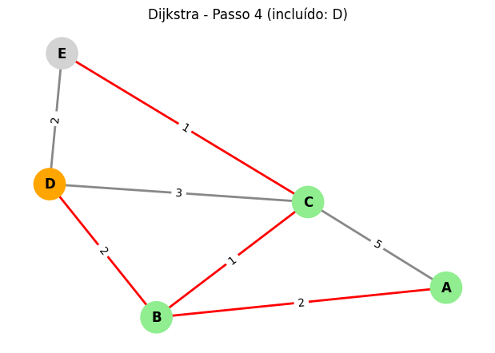

```
Passo 5:
  Vértice escolhido: E (dv=4)
  Custos mínimos (dv): {'A': 0, 'B': 2, 'C': 3, 'D': 4, 'E': 4}
  Predecessores (pv): {'A': None, 'B': 'A', 'C': 'B', 'D': 'B', 'E': 'C'}
  Visitados: {'A', 'D', 'B', 'E', 'C'}
```

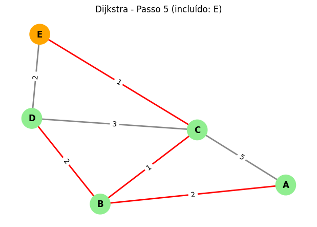

```
Resultado final de Dijkstra a partir de A:
Custos mínimos (dv): {'A': 0, 'B': 2, 'C': 3, 'D': 4, 'E': 4}
Predecessores (pv): {'A': None, 'B': 'A', 'C': 'B', 'D': 'B', 'E': 'C'}
```

```python
# Dijkstra passo a passo a partir do vértice A

import networkx as nx
import matplotlib.pyplot as plt
import pandas as pd

G9 = nx.Graph()
G9.add_weighted_edges_from([
    ('A', 'B', 2),
    ('A', 'C', 5),
    ('B', 'C', 1),
    ('B', 'D', 2),
    ('C', 'D', 3),
    ('C', 'E', 1),
    ('D', 'E', 2)
])

vertices = ['A', 'B', 'C', 'D', 'E']
dv = {v: float('inf') for v in vertices}
pv = {v: None for v in vertices}
dv['A'] = 0
visitados = set()

pos = nx.spring_layout(G9, seed=42)

print("Passo 0: Inicialização")
print("  Custos mínimos (dv):", dv)
print("  Predecessores (pv):", pv)
print("  Visitados:", visitados)
plt.figure(figsize=(6,4))
nx.draw(G9, pos, with_labels=True, node_color=['orange' if n == 'A' else 'lightgray' for n in G9.nodes], node_size=800, font_weight='bold', edge_color='#888', width=2)
labels = nx.get_edge_attributes(G9, 'weight')
nx.draw_networkx_edge_labels(G9, pos, edge_labels=labels)
plt.title("Dijkstra - Passo 0 (início)")
plt.show()

passo = 1
while len(visitados) < len(vertices):
    # Seleciona o vértice não visitado de menor custo
    u = min((v for v in vertices if v not in visitados), key=lambda v: dv[v])
    visitados.add(u)
    print(f"\nPasso {passo}:")
    print(f"  Vértice escolhido: {u} (dv={dv[u]})")
    for v in G9.neighbors(u):
        if v not in visitados:
            custo = G9[u][v]['weight']
            if dv[v] > dv[u] + custo:
                print(f"    * Atualizando dv[{v}]: {dv[v]} → {dv[u] + custo} (via {u})")
                dv[v] = dv[u] + custo
                pv[v] = u
    print("  Custos mínimos (dv):", dv)
    print("  Predecessores (pv):", pv)
    print("  Visitados:", visitados)

    # Visualização do grafo no passo
    node_colors = ['orange' if n == u else ('lightgreen' if n in visitados else 'lightgray') for n in G9.nodes]
    edge_colors = []
    for e in G9.edges:
        if (pv[e[1]] == e[0]) or (pv[e[0]] == e[1]):
            edge_colors.append('red')
        else:
            edge_colors.append('#888')
    plt.figure(figsize=(6,4))
    nx.draw(G9, pos, with_labels=True, node_color=node_colors, node_size=800, font_weight='bold', edge_color=edge_colors, width=2)
    nx.draw_networkx_edge_labels(G9, pos, edge_labels=labels)
    plt.title(f"Dijkstra - Passo {passo} (incluído: {u})")
    plt.show()
    passo += 1

print("\nResultado final de Dijkstra a partir de A:")
print("Custos mínimos (dv):", dv)
print("Predecessores (pv):", pv)
```

### Questão 10: Matriz de custos (matriz de adjacência valorada) de um grafo de cidades

Uma empresa de energia está planejando instalar cabos entre cinco cidades: A, B, C, D e E. O custo de instalação entre cada par de cidades está representado nas arestas do grafo abaixo:

- Arestas e custos:
  - A–B: 4
  - A–C: 7
  - B–C: 2
  - B–D: 5
  - C–D: 3
  - C–E: 6
  - D–E: 1

Monte a matriz de custos (matriz de adjacência valorada) desse grafo e explique como ela representa os custos de instalação entre as cidades.

```
Matriz de custos (matriz de adjacência valorada):
     A    B    C    D    E
A  0.0  4.0  7.0    ∞    ∞
B  4.0  0.0  2.0  5.0    ∞
C  7.0  2.0  0.0  3.0  6.0
D    ∞  5.0  3.0  0.0  1.0
E    ∞    ∞  6.0  1.0  0.0
```

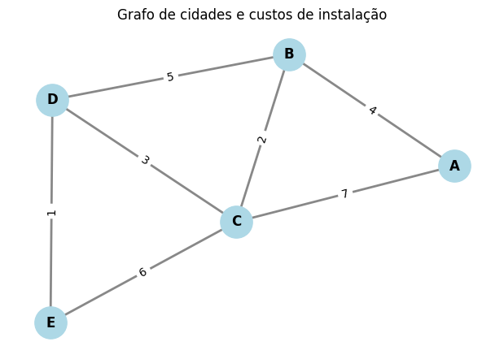

```
Explicação:
A matriz de adjacência valorada mostra o custo mínimo para instalar cabos entre cada par de cidades.
Se não existe ligação direta entre duas cidades, o valor é ∞ (infinito).
A diagonal principal é zero, pois o custo de uma cidade para ela mesma é zero.
```

```python
# Questão 10: Matriz de custos (matriz de adjacência valorada)

import networkx as nx
import pandas as pd

G10 = nx.Graph()
G10.add_weighted_edges_from([
    ('A', 'B', 4),
    ('A', 'C', 7),
    ('B', 'C', 2),
    ('B', 'D', 5),
    ('C', 'D', 3),
    ('C', 'E', 6),
    ('D', 'E', 1)
])

vertices = ['A', 'B', 'C', 'D', 'E']
matriz = pd.DataFrame(float('inf'), index=vertices, columns=vertices)
for u, v, data in G10.edges(data=True):
    matriz.loc[u, v] = data['weight']
    matriz.loc[v, u] = data['weight']
for v in vertices:
    matriz.loc[v, v] = 0

print("Matriz de custos (matriz de adjacência valorada):")
print(matriz.replace(float('inf'), '∞'))

# Visualização do grafo
import matplotlib.pyplot as plt
pos = nx.spring_layout(G10, seed=42)
plt.figure(figsize=(6,4))
nx.draw(G10, pos, with_labels=True, node_color='lightblue', node_size=800, font_weight='bold', edge_color='#888', width=2)
labels = nx.get_edge_attributes(G10, 'weight')
nx.draw_networkx_edge_labels(G10, pos, edge_labels=labels)
plt.title("Grafo de cidades e custos de instalação")
plt.show()

# Explicação:
print("\nExplicação:")
print("A matriz de adjacência valorada mostra o custo mínimo para instalar cabos entre cada par de cidades.")
print("Se não existe ligação direta entre duas cidades, o valor é ∞ (infinito).")
print("A diagonal principal é zero, pois o custo de uma cidade para ela mesma é zero.")
```